# Arbeitsblatt 6

Autor:

Anna Drewek

Version vom:

24. Oktober 2024

## Aufgabe 1: API Gender

Auf dem Arbeitsblatt 3 haben Sie nachfolgende Liste aufbereitet und dabei das Geschlecht mit Regular Expressions aus der Endung des Berufs extrahiert. In dieser Aufgabe sollen Sie das Geschlecht unter Verwendung einer API bestimmen.

```r
library(stringr)
spitalX <- c("Arzt Stefan", "Pfleger Heinz", "Pflegerin Julia",
"Ärztin Petra", "Aerztin Patricia", "Praktikantin Mona",
"Arzt Claude", "Arzt Ciril")
dat <- data.frame(Orig = spitalX)
dat$Name <- str_match(spitalX,"[A-Z][a-z]+$")
dat
```

| Orig | Name |
| --- | --- |
| Arzt Stefan | Stefan |
| Pfleger Heinz | Heinz |
| Pflegerin Julia | Julia |
| Ärztin Petra | Petra |
| Aerztin Patricia | Patricia |
| Praktikantin Mona | Mona |
| Arzt Claude | Claude |
| Arzt Ciril | Ciril |

Das Geschlecht einer Person kann mit folgender API https://api.genderize.io abgefragt werden. Der Abfrageparameter ist name.

### Teilaufgabe a

Bestimmen Sie das Geschlecht Ihres Namens.

```
Response [https://api.genderize.io/?name=oliver]
  Date: 2024-10-24 16:57
  Status: 200
  Content-Type: application/json; charset=utf-8
  Size: 67 B
```

| count | name | gender | probability |
| --- | --- | --- | --- |
| 218769 | oliver | male | 0.99 |

### Teilaufgabe b

spitalX Daten Bestimmen Sie das Geschlecht der Personen in den spitalX Daten. Fügen Sie das Geschlecht nur dann den Daten hinzu, wenn eine Wahrscheinlichkeit über 90% angegeben wird.

[output not shown]

## Aufgabe 2: Länderinformationen

Lesen Sie die Dokumentation zur API auf der Webseite durch. Führen Sie einen geeig- neten Befehl in R aus, um von der API Informationen zur Schweiz zu erhalten. Welche Bevölkerungsgrösse (Population) wird von der API für die Schweiz angegeben?

```
[1] 8654622
```

### Teilaufgabe b

Fügen Sie mit Hilfe der API nachfolgendem Datensatz eine neue Variable hinzu, die beschreibt, ob der Kunde von Europa oder nicht von Europa stammt. Variante 1

```r
library(httr)
library(jsonlite)

kunden <- data.frame(Name = c("Peter","Pedro","Olaf",
"Juan","Paul","Luis"),
Land = c("United States","Mexico","Norway",
"Spain","Switzerland","Brazil"))

kunden$Europa <- NA
for(i in 1:nrow(kunden)){
  country <- URLencode(kunden$Land[i])
  adress <- modify_url(url = paste0("https://restcountries.com/v3.1/name/", country),
                       path = NULL)

  res <- GET(adress)
  if(status_code(res) == 200){
  datapi <- as.data.frame(fromJSON(rawToChar(res$content)))
  kunden$Europa[i] <- ifelse(datapi$region == "Europe", "Europa", datapi$subregion)
  } else {
  kunden$Europa[i] <- NA
  }
}
kunden
```

| Name | Land | Europa |
| --- | --- | --- |
| Peter | United States | North America |
| Pedro | Mexico | North America |
| Olaf | Norway | Europa |
| Juan | Spain | Europa |
| Paul | Switzerland | Europa |
| Luis | Brazil | South America |

Variante 2

```r
library(httr)
library(jsonlite)

address <- "https://restcountries.com/v3.1/region/europe"
res <- GET(url=address) # API-Anfrage
res
```

```
Response [https://restcountries.com/v3.1/region/europe]
  Date: 2024-10-24 16:57
  Status: 200
  Content-Type: application/json
  Size: 170 kB
```

```r
dat <- fromJSON(rawToChar(res$content))
dat$name$common
```

```
 [1] "Norway"                 "Greece"                 "Åland Islands"
 [4] "Switzerland"            "Croatia"                "Iceland"
 [7] "Luxembourg"             "Hungary"                "Netherlands"
[10] "Lithuania"              "Slovakia"               "Liechtenstein"
[13] "Moldova"                "Italy"                  "Jersey"
[16] "Monaco"                 "Belarus"                "Latvia"
[19] "Andorra"                "France"                 "Gibraltar"
[22] "Denmark"                "North Macedonia"        "Malta"
[25] "Czechia"                "Guernsey"               "Kosovo"
[28] "Svalbard and Jan Mayen" "Montenegro"             "Faroe Islands"
[31] "Albania"                "Serbia"                 "Ukraine"
[34] "Isle of Man"            "Estonia"                "Romania"
[37] "Bulgaria"               "Germany"                "Poland"
[40] "United Kingdom"         "Finland"                "Sweden"
[43] "Vatican City"           "Russia"                 "Austria"
[46] "Cyprus"                 "Portugal"               "Bosnia and Herzegovina"
[49] "Belgium"                "Spain"                  "Slovenia"
[52] "San Marino"             "Ireland"
```

```r
kunden$Europa <- ifelse(kunden$Land %in% dat$name$common, "Europe", "elsewhere")
kunden
```

| Name | Land | Europa |
| --- | --- | --- |
| Peter | United States | elsewhere |
| Pedro | Mexico | elsewhere |
| Olaf | Norway | Europe |
| Juan | Spain | Europe |
| Paul | Switzerland | Europe |
| Luis | Brazil | elsewhere |

Im Auftrag von Scotland Yard sollen die Hotspots von Waffengewalt ermittelt werden. Im Datensatz weapons_london.Rdata sind alle Verbrechen im Zusammenhang mit Waffenbesitz aus der London Metropolitan Area für August 2020 aufgelistet (Quelle: https://data.police.uk/data/).

### Teilaufgabe a

Stellen Sie den Längengrad (Longitude) auf der x-Achse und den Breitengrad (Latitude) auf der y-Achse in einem gewöhnlichen Streudiagramm dar.

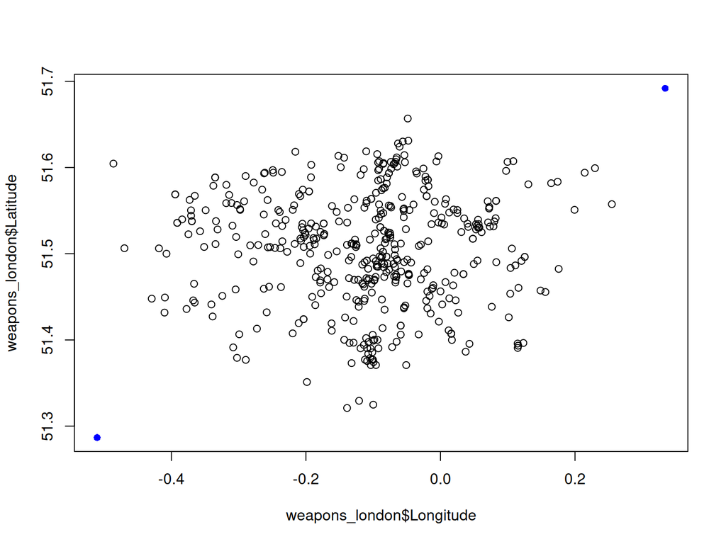

### Teilaufgabe b

Erweitern Sie die Darstellung, in dem Sie die Punkte auf einer Karte von London einzeichnen. Sie können dazu Google Maps, OpenStreetMap oder Stadia verwenden.

```r
library(leaflet)
leaflet()  |>
  addTiles()  |>
  addCircleMarkers(lng = weapons_london$Longitude,
                   lat = weapons_london$Latitude,
                   popup = weapons_london$Location,
                   radius = 3,
                   color = "blue",
                   fillOpacity = 0.8,
                   stroke = FALSE)
```

[interactive chart not shown]